# SPWM Notebook

TODO: check sub78’s raw data to explain low accuracy data

# SPWM PRE DATA ANALYSIS

N=56 (Control+Experimental) There is a 3rd undefined group for those that have completed this task, but have dropped out for one reason or another.

## Data Prep

Getting the Data ready for analysis Defaults: R uses dummy coding as it’s default. In this sample, the control group and the four_m will be the dummy variables in the analysis. So all Estimates are relative to these dummy variables

### Load Requisite R Packages

note: some of these may not actually be used.

```r
library(ggplot2)
library(lme4)
library(languageR)
library(lmerTest) #give p-values from mixed models
library(influence.ME)
library(plyr) # magic
library(scales) #for making percents on the y-axis of graphs
```

### Read in the dataset (in current directory)

```r
SPWM_data = read.table("SPWM_R_format.csv", header = TRUE, sep = ",")
```

### omit missing data (e.g. from practice trials)

```r
SPWM_data = na.omit(SPWM_data)
head(SPWM_data, n = 20)
```

### Omit the Undefined group from the data and specify group as a factor

```r
SPWM_data <- subset(SPWM_data,group=="Control" | group=="Experimental")
SPWM_data$group <- factor(SPWM_data$group)
summary(SPWM_data)
contrasts(SPWM_data$group)
```

### Omit the Undefined stimtype and specify stimtype as a factor

```r
SPWM_data <- subset(SPWM_data,stimtype=="four_m" | stimtype=="four_nm")
SPWM_data$stimtype <- factor(SPWM_data$stimtype)
summary(SPWM_data)
contrasts(SPWM_data$stimtype)
```

### Isolate the session to the first session

```r
SPWM_data_pre <- subset(SPWM_data, session==1)
SPWM_data_pre$session <- factor(SPWM_data_pre$session)
summary(SPWM_data_pre)
```

### Specify subject as a factor

```r
SPWM_data_pre$subject <- as.factor(SPWM_data_pre$subject)

summary(SPWM_data_pre)
```

## SPWN Accuracy Analysis

### Print Accuracy data for each subject for each group

```r
#Control Group Data
SPWM_data_pre_control <- subset(SPWM_data_pre, group=="Control")
#change binary data to a percent
SPWM_data_pre_control_percent <- ddply(SPWM_data_pre_control, .(stimtype, subject), summarize, ACC_perc = mean(ACC))

#Experimental Group Data
SPWM_data_pre_experimental <- subset(SPWM_data_pre, group=="Experimental")
#change binary data to a percent
SPWM_data_pre_experimental_percent <- ddply(SPWM_data_pre_experimental, .(stimtype, subject), summarize, ACC_perc = mean(ACC))

ggplot(data = SPWM_data_pre_control_percent, aes( x = stimtype, y = ACC_perc)) + geom_bar(stat = "identity", width = 0.5) + facet_wrap(~subject) + scale_y_continuous(labels=percent) + scale_x_discrete(labels=c("four_m","four_nm")) + ggtitle("Control")

ggplot(data = SPWM_data_pre_experimental_percent, aes( x = stimtype, y = ACC_perc)) + geom_bar(stat = "identity", width = 0.5) + facet_wrap(~subject) + scale_y_continuous(labels=percent) +  scale_x_discrete(labels=c("four_m","four_nm")) + ggtitle("Experimental")
```

[output not shown]

**Conclusion**: sub78,sub164, and sub190 have worrying low accuracy for the non-matching conditions. In fact sub78 did not get any right, should check the raw data to see if they were pressing the wrong key. Otherwise data appear fine.

### Model Accuracy (Logit)

```r
SPWM_ACC_model<-glmer(ACC ~ group*stimtype + (1|subject), family=binomial, data=SPWM_data_pre, verbose=TRUE)
summary(SPWM_ACC_model)
```

[output not shown]

**Conclusion**: No main effect of group (as expected), but there is an interaction, suggesting some outliers may be influencing the four_nm accuracy measure (looking at you guys: sub78,sub164,sub190).

## Reaction Time Analysis

### Format RT data

(subset for RTs when they are accurate, greater than 200ms, and less than 5000 ms) (speed wasn’t as important in this task) See how many observations are lost when we subset the data

```r
#all observations
print("All Data")
```

```
[1] "All Data"
```

```r
All_data <- length(SPWM_data_pre$RT)
summary(SPWM_data_pre)
```

```
    subject     session           group         stimtype         ACC               RT
 5      :  60   1:3360   Control     :1740   four_m :1680   Min.   :0.0000   Min.   :   0
 6      :  60            Experimental:1620   four_nm:1680   1st Qu.:1.0000   1st Qu.: 922
 7      :  60                                               Median :1.0000   Median :1154
 8      :  60                                               Mean   :0.7503   Mean   :1111
 9      :  60                                               3rd Qu.:1.0000   3rd Qu.:1396
 10     :  60                                               Max.   :1.0000   Max.   :1897
 (Other):3000
```

```r
#remove innacurate responses
print("Removed innacurate trials (from all data dataframe)")
```

```
[1] "Removed innacurate trials (from all data dataframe)"
```

```r
SPWM_data_pre_RT <- subset(SPWM_data_pre, ACC==1)
All_Acc_Data <- length(SPWM_data_pre_RT$RT)
summary(SPWM_data_pre_RT)
```

```
    subject     session           group         stimtype         ACC          RT
 51     :  53   1:2521   Control     :1282   four_m :1248   Min.   :1   Min.   : 145
 113    :  53            Experimental:1239   four_nm:1273   1st Qu.:1   1st Qu.: 976
 9      :  52                                               Median :1   Median :1170
 10     :  52                                               Mean   :1   Mean   :1188
 87     :  52                                               3rd Qu.:1   3rd Qu.:1394
 6      :  51                                               Max.   :1   Max.   :1897
 (Other):2208
```

```r
#remove short and long RTs
print("Removed slow and fast RTs")
```

```
[1] "Removed slow and fast RTs"
```

```r
SPWM_data_pre_RT <- subset(SPWM_data_pre_RT, RT>200 & RT<5000)
filtered_data <- length(SPWM_data_pre_RT$RT)
summary(SPWM_data_pre_RT)
```

```
    subject     session           group         stimtype         ACC          RT
 51     :  53   1:2520   Control     :1282   four_m :1247   Min.   :1   Min.   : 441.0
 113    :  53            Experimental:1238   four_nm:1273   1st Qu.:1   1st Qu.: 976.8
 9      :  52                                               Median :1   Median :1170.0
 10     :  52                                               Mean   :1   Mean   :1188.3
 87     :  52                                               3rd Qu.:1   3rd Qu.:1394.2
 6      :  51                                               Max.   :1   Max.   :1897.0
 (Other):2207
```

```r
print("Percentage of Data Removed")
```

```
[1] "Percentage of Data Removed"
```

```r
perc_data_rm <- (1 - (filtered_data/All_Acc_Data)) * 100
perc_data_rm
```

```
[1] 0.0396668
```

**Conclusion**: Almost no data is filtered out because of the RTs, looks like one fast response was removed.

### Graph RT data

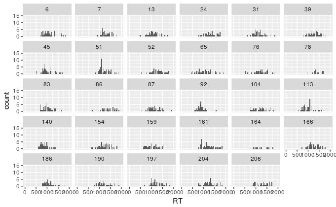

```r
#hist(subset(SPWM_data_pre_RT, group=="Control")$RT,ylim=c(0,300))
#hist(subset(SPWM_data_pre_RT, group=="Experimental")$RT,ylim=c(0,300))
SPWM_data_pre_RT_control <- subset(SPWM_data_pre_RT, group=="Control")
SPWM_data_pre_RT_experimental <- subset(SPWM_data_pre_RT, group=="Experimental")
#collapsing across stimtype (four_m, four_nm), not enough data to make a good histogram, and the graphs become too crowded if I include stimtype as a facet
RT_hist_control <- ggplot(data = SPWM_data_pre_RT_control, aes(RT)) + geom_histogram(binwidth = 30) + facet_wrap(~subject) + scale_y_continuous(limits = c(0,15)) + scale_x_continuous(limits = c(0,2000))
print(RT_hist_control)
```

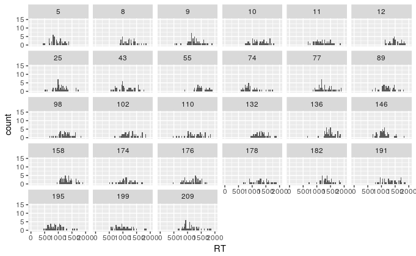

```r
RT_hist_experimental <- ggplot(data = SPWM_data_pre_RT_experimental, aes(RT)) + geom_histogram(binwidth = 30) + facet_wrap(~subject) + scale_y_continuous(limits = c(0,15)) + scale_x_continuous(limits = c(0,2000))
print(RT_hist_experimental)
```

**Conclusion**: this RT data does not need to be transformed, looks roughly normal, but I will transform it anyway to see how it looks

### Log Transform RT data

```r
SPWM_data_pre_RT$log_RT <- log(1/SPWM_data_pre_RT$RT)
```

Step 13) Graph RT data that should look more normally distributed

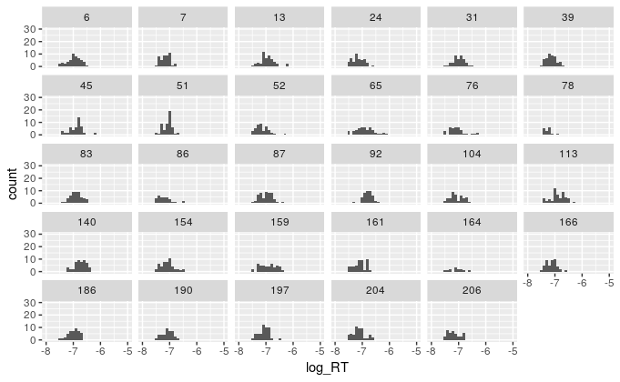

```r
SPWM_data_pre_RT_control <- subset(SPWM_data_pre_RT, group=="Control")
SPWM_data_pre_RT_experimental <- subset(SPWM_data_pre_RT, group=="Experimental")
#collapsing across stimtype (four_m, four_nm), not enough data to make a good histogram, and the graphs become too crowded if I include stimtype as a facet
RT_hist_control <- ggplot(data = SPWM_data_pre_RT_control, aes(log_RT)) + geom_histogram(binwidth = .1) + facet_wrap(~subject) + scale_y_continuous(limits = c(0,30)) + scale_x_continuous(limits = c(-8,-5))
print(RT_hist_control)
```

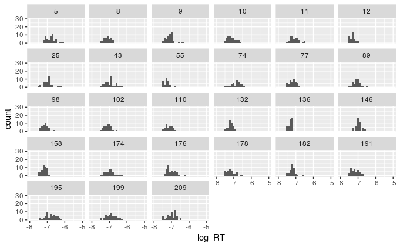

```r
RT_hist_experimental <- ggplot(data = SPWM_data_pre_RT_experimental, aes(log_RT)) + geom_histogram(binwidth = .1) + facet_wrap(~subject) + scale_y_continuous(limits = c(0,30)) + scale_x_continuous(limits = c(-8,-5))
print(RT_hist_experimental)
```

**Conclusion**: Using untransformed data because they look more normal (at least overall)

### Model RT

```r
SPWM_RT_model <- lmer(RT ~ group*stimtype + (1|subject), data = SPWM_data_pre_RT)
summary(SPWM_RT_model)
```

```
Linear mixed model fit by REML t-tests use Satterthwaite approximations to degrees of  freedom
 [lmerMod]
Formula: RT ~ group * stimtype + (1 | subject)
   Data: SPWM_data_pre_RT

REML criterion at convergence: 35334.5

Scaled residuals:
    Min      1Q  Median      3Q     Max
-2.9853 -0.6610 -0.1118  0.6155  3.2554

Random effects:
 Groups   Name        Variance Std.Dev.
 subject  (Intercept) 19495    139.6
 Residual             68871    262.4
Number of obs: 2520, groups:  subject, 56

Fixed effects:
                                  Estimate Std. Error       df t value Pr(>|t|)
(Intercept)                       1168.089     27.956   61.800  41.782   <2e-16 ***
groupExperimental                   67.854     40.249   61.800   1.686   0.0969 .
stimtypefour_nm                      5.808     14.855 2467.200   0.391   0.6959
groupExperimental:stimtypefour_nm  -29.778     21.104 2461.100  -1.411   0.1584
---
Signif. codes:  0 ‘***’ 0.001 ‘**’ 0.01 ‘*’ 0.05 ‘.’ 0.1 ‘ ’ 1

Correlation of Fixed Effects:
            (Intr) grpExp stmty_
grpExprmntl -0.695
stmtypfr_nm -0.255  0.177
grpExprmn:_  0.179 -0.261 -0.704
```

**Conclusion**: the experimental group is trending a slightly slower RT than the Control group overall. Otherwise no modeled differences found.

### Model log_RT

Note: maybe the raw RTs do violate assumptions of normality

```r
SPWM_log_RT_model <- lmer(log_RT ~ group*stimtype + (1|subject), data = SPWM_data_pre_RT)
summary(SPWM_log_RT_model)
```

```
Linear mixed model fit by REML t-tests use Satterthwaite approximations to degrees of  freedom
 [lmerMod]
Formula: log_RT ~ group * stimtype + (1 | subject)
   Data: SPWM_data_pre_RT

REML criterion at convergence: -84.1

Scaled residuals:
    Min      1Q  Median      3Q     Max
-2.8248 -0.6606  0.0016  0.5911  3.9818

Random effects:
 Groups   Name        Variance Std.Dev.
 subject  (Intercept) 0.01581  0.1257
 Residual             0.05295  0.2301
Number of obs: 2520, groups:  subject, 56

Fixed effects:
                                    Estimate Std. Error         df  t value Pr(>|t|)
(Intercept)                         -7.02795    0.02508   61.60000 -280.184   <2e-16 ***
groupExperimental                   -0.05745    0.03611   61.50000   -1.591    0.117
stimtypefour_nm                     -0.01140    0.01303 2477.20000   -0.875    0.382
groupExperimental:stimtypefour_nm    0.02840    0.01851 2471.30000    1.535    0.125
---
Signif. codes:  0 ‘***’ 0.001 ‘**’ 0.01 ‘*’ 0.05 ‘.’ 0.1 ‘ ’ 1

Correlation of Fixed Effects:
            (Intr) grpExp stmty_
grpExprmntl -0.695
stmtypfr_nm -0.249  0.173
grpExprmn:_  0.175 -0.255 -0.704
```

**Conclusion**: The trending difference disappeared (now we have to decide which analysis is more valid), thought: get a quantitative measure for skew and normality and see if log or raw RT is better.

## Conclusions:

Good: No statistically significant differences between groups in either ACC or RT

Bad: There is a trend where experimental RT is slower than Control RT ^This disappears with log_RT a couple of subjects have abnormally low accuracy in the non-matching condition.